# Risk Factor Analysis

## Outcome Variable

**Outcome Variable:** haz

## Predictor Variables

**Intervention Variable:** fage

**Adjustment Set:**

- arm
- W_mage
- meducyrs
- feducyrs
- W_mhtcm
- W_mwtkg
- W_mbmi
- W_fhtcm
- single
- brthmon
- delta_W_mage
- delta_meducyrs
- delta_feducyrs
- delta_W_mhtcm
- delta_W_mwtkg
- delta_W_mbmi
- delta_W_fhtcm
- delta_single
- delta_brthmon

## Stratifying Variables

The analysis was stratified on these variable(s):

- agecat
- studyid
- country

## Data Summary

| agecat | studyid | country | fage | n_cell | n | outcome_variable |
| --- | --- | --- | --- | --- | --- | --- |
| Birth | COHORTS | GUATEMALA | >=38 | 245 | 823 | haz |
| Birth | COHORTS | GUATEMALA | <32 | 380 | 823 | haz |
| Birth | COHORTS | GUATEMALA | [32-38) | 198 | 823 | haz |
| Birth | COHORTS | PHILIPPINES | >=38 | 328 | 2944 | haz |
| Birth | COHORTS | PHILIPPINES | <32 | 2079 | 2944 | haz |
| Birth | COHORTS | PHILIPPINES | [32-38) | 537 | 2944 | haz |
| Birth | MAL-ED | BANGLADESH | >=38 | 63 | 133 | haz |
| Birth | MAL-ED | BANGLADESH | <32 | 25 | 133 | haz |
| Birth | MAL-ED | BANGLADESH | [32-38) | 45 | 133 | haz |
| Birth | MAL-ED | BRAZIL | >=38 | 6 | 18 | haz |
| Birth | MAL-ED | BRAZIL | <32 | 1 | 18 | haz |
| Birth | MAL-ED | BRAZIL | [32-38) | 11 | 18 | haz |
| Birth | MAL-ED | INDIA | >=38 | 7 | 27 | haz |
| Birth | MAL-ED | INDIA | <32 | 9 | 27 | haz |
| Birth | MAL-ED | INDIA | [32-38) | 11 | 27 | haz |
| Birth | MAL-ED | NEPAL | >=38 | 2 | 9 | haz |
| Birth | MAL-ED | NEPAL | <32 | 2 | 9 | haz |
| Birth | MAL-ED | NEPAL | [32-38) | 5 | 9 | haz |
| Birth | MAL-ED | PERU | >=38 | 23 | 69 | haz |
| Birth | MAL-ED | PERU | <32 | 22 | 69 | haz |
| Birth | MAL-ED | PERU | [32-38) | 24 | 69 | haz |
| Birth | MAL-ED | SOUTH AFRICA | >=38 | 17 | 31 | haz |
| Birth | MAL-ED | SOUTH AFRICA | <32 | 5 | 31 | haz |
| Birth | MAL-ED | SOUTH AFRICA | [32-38) | 9 | 31 | haz |
| Birth | MAL-ED | TANZANIA, UNITED REPUBLIC OF | >=38 | 19 | 46 | haz |
| Birth | MAL-ED | TANZANIA, UNITED REPUBLIC OF | <32 | 9 | 46 | haz |
| Birth | MAL-ED | TANZANIA, UNITED REPUBLIC OF | [32-38) | 18 | 46 | haz |
| Birth | PROBIT | BELARUS | >=38 | 606 | 13399 | haz |
| Birth | PROBIT | BELARUS | <32 | 10732 | 13399 | haz |
| Birth | PROBIT | BELARUS | [32-38) | 2061 | 13399 | haz |

[output cut: 75 more lines]

The following strata were considered:

- agecat: 24 months, studyid: COHORTS, country: GUATEMALA
- agecat: 24 months, studyid: COHORTS, country: PHILIPPINES
- agecat: 24 months, studyid: LCNI-5, country: MALAWI
- agecat: 24 months, studyid: MAL-ED, country: BANGLADESH
- agecat: 24 months, studyid: MAL-ED, country: BRAZIL
- agecat: 24 months, studyid: MAL-ED, country: INDIA
- agecat: 24 months, studyid: MAL-ED, country: NEPAL
- agecat: 24 months, studyid: MAL-ED, country: PERU
- agecat: 24 months, studyid: MAL-ED, country: SOUTH AFRICA
- agecat: 24 months, studyid: MAL-ED, country: TANZANIA, UNITED REPUBLIC OF
- agecat: 24 months, studyid: PROBIT, country: BELARUS
- agecat: 6 months, studyid: COHORTS, country: GUATEMALA
- agecat: 6 months, studyid: COHORTS, country: PHILIPPINES
- agecat: 6 months, studyid: LCNI-5, country: MALAWI
- agecat: 6 months, studyid: MAL-ED, country: BANGLADESH
- agecat: 6 months, studyid: MAL-ED, country: BRAZIL
- agecat: 6 months, studyid: MAL-ED, country: INDIA
- agecat: 6 months, studyid: MAL-ED, country: NEPAL
- agecat: 6 months, studyid: MAL-ED, country: PERU
- agecat: 6 months, studyid: MAL-ED, country: SOUTH AFRICA
- agecat: 6 months, studyid: MAL-ED, country: TANZANIA, UNITED REPUBLIC OF
- agecat: 6 months, studyid: PROBIT, country: BELARUS
- agecat: 6 months, studyid: SAS-CompFeed, country: INDIA
- agecat: 6 months, studyid: SAS-FoodSuppl, country: INDIA
- agecat: Birth, studyid: COHORTS, country: GUATEMALA
- agecat: Birth, studyid: COHORTS, country: PHILIPPINES
- agecat: Birth, studyid: MAL-ED, country: BANGLADESH
- agecat: Birth, studyid: MAL-ED, country: BRAZIL
- agecat: Birth, studyid: MAL-ED, country: INDIA
- agecat: Birth, studyid: MAL-ED, country: NEPAL
- agecat: Birth, studyid: MAL-ED, country: PERU
- agecat: Birth, studyid: MAL-ED, country: SOUTH AFRICA
- agecat: Birth, studyid: MAL-ED, country: TANZANIA, UNITED REPUBLIC OF
- agecat: Birth, studyid: PROBIT, country: BELARUS
- agecat: Birth, studyid: SAS-CompFeed, country: INDIA

### Dropped Strata

Some strata were dropped due to rare outcomes:

- agecat: Birth, studyid: MAL-ED, country: BRAZIL
- agecat: Birth, studyid: MAL-ED, country: NEPAL

## Methods Detail

We’re interested in the causal parameters $E[Y_a]$ for all values of $a \in \mathcal{A}$. These parameters represent the mean outcome if, possibly contrary to fact, we intervened to set all units to have $A=a$. Under the randomization and positivity assumptions, these are identified by the statistical parameters $\psi_a=E_W[E_{Y|A,W}(Y|A=a,W)]$. In addition, we’re interested in the mean of $Y$, $E[Y]$ under no intervention (the observed mean). We will estimate these parameters by using SuperLearner to fit the relevant likelihood factors – $E_{Y|A,W}(Y|A=a,W)$ and $p(A=a|W)$, and then updating our likelihood fit using a joint TMLE.

For unadjusted analyses ($W=\{\}$), initial likelihoods were estimated using Lrnr_glm to estimate the simple $E(Y|A)$ and Lrnr_mean to estimate $p(A)$. For adjusted analyses, a small library containing Lrnr_glmnet, Lrnr_xgboost, and Lrnr_mean was used.

Having estimated these parameters, we will then use the delta method to estimate relative risks and attributable risks relative to a prespecified baseline level of $A$.

# Results Detail

## Results Plots

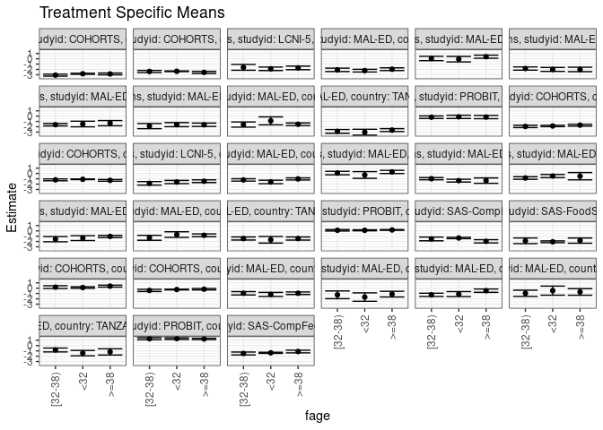

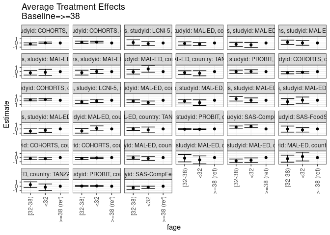

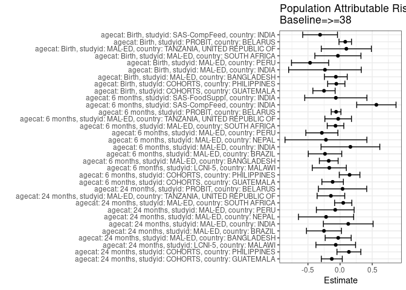

## Results Table

### Parameter: TSM

| agecat | studyid | country | intervention_level | baseline_level | estimate | ci_lower | ci_upper |
| --- | --- | --- | --- | --- | --- | --- | --- |
| Birth | COHORTS | GUATEMALA | >=38 | NA | 0.3878066 | 0.2031740 | 0.5724393 |
| Birth | COHORTS | GUATEMALA | <32 | NA | 0.1243698 | -0.0179268 | 0.2666663 |
| Birth | COHORTS | GUATEMALA | [32-38) | NA | 0.2020205 | -0.0573444 | 0.4613855 |
| Birth | COHORTS | PHILIPPINES | >=38 | NA | -0.1879427 | -0.3247854 | -0.0511001 |
| Birth | COHORTS | PHILIPPINES | <32 | NA | -0.2567169 | -0.3179644 | -0.1954693 |
| Birth | COHORTS | PHILIPPINES | [32-38) | NA | -0.4180248 | -0.6224818 | -0.2135677 |
| Birth | MAL-ED | BANGLADESH | >=38 | NA | -0.9441518 | -1.1820540 | -0.7062496 |
| Birth | MAL-ED | BANGLADESH | <32 | NA | -1.1697057 | -1.5490752 | -0.7903362 |
| Birth | MAL-ED | BANGLADESH | [32-38) | NA | -0.9539175 | -1.2651437 | -0.6426912 |
| Birth | MAL-ED | INDIA | >=38 | NA | -1.1171429 | -1.6489224 | -0.5853634 |
| Birth | MAL-ED | INDIA | <32 | NA | -1.6666667 | -2.4558740 | -0.8774593 |
| Birth | MAL-ED | INDIA | [32-38) | NA | -1.2445455 | -1.9691474 | -0.5199435 |
| Birth | MAL-ED | PERU | >=38 | NA | -0.4667783 | -0.7768208 | -0.1567358 |
| Birth | MAL-ED | PERU | <32 | NA | -1.1058944 | -1.5725310 | -0.6392577 |
| Birth | MAL-ED | PERU | [32-38) | NA | -1.2446216 | -1.5506393 | -0.9386039 |
| Birth | MAL-ED | SOUTH AFRICA | >=38 | NA | -0.7005882 | -1.3189739 | -0.0822026 |
| Birth | MAL-ED | SOUTH AFRICA | <32 | NA | -0.4560000 | -1.3078853 | 0.3958853 |
| Birth | MAL-ED | SOUTH AFRICA | [32-38) | NA | -0.9533333 | -1.5323681 | -0.3742986 |
| Birth | MAL-ED | TANZANIA, UNITED REPUBLIC OF | >=38 | NA | -1.1921053 | -1.7757068 | -0.6085037 |
| Birth | MAL-ED | TANZANIA, UNITED REPUBLIC OF | <32 | NA | -1.4211111 | -1.9248904 | -0.9173319 |
| Birth | MAL-ED | TANZANIA, UNITED REPUBLIC OF | [32-38) | NA | -0.8288889 | -1.1916650 | -0.4661127 |
| Birth | PROBIT | BELARUS | >=38 | NA | 1.2395054 | 1.1183525 | 1.3606583 |
| Birth | PROBIT | BELARUS | <32 | NA | 1.3087212 | 1.1544951 | 1.4629473 |
| Birth | PROBIT | BELARUS | [32-38) | NA | 1.2860938 | 1.0911387 | 1.4810490 |
| Birth | SAS-CompFeed | INDIA | >=38 | NA | -1.1191180 | -1.3708200 | -0.8674161 |
| Birth | SAS-CompFeed | INDIA | <32 | NA | -1.3666939 | -1.4728651 | -1.2605227 |
| Birth | SAS-CompFeed | INDIA | [32-38) | NA | -1.4884439 | -1.7560242 | -1.2208637 |
| 6 months | COHORTS | GUATEMALA | >=38 | NA | -1.6909263 | -1.8694559 | -1.5123968 |
| 6 months | COHORTS | GUATEMALA | <32 | NA | -1.8519463 | -1.9721189 | -1.7317738 |
| 6 months | COHORTS | GUATEMALA | [32-38) | NA | -1.9397339 | -2.1559965 | -1.7234714 |

[output cut: 69 more lines]

### Parameter: E(Y)

| agecat | studyid | country | intervention_level | baseline_level | estimate | ci_lower | ci_upper |
| --- | --- | --- | --- | --- | --- | --- | --- |
| Birth | COHORTS | GUATEMALA | NA | NA | 0.1377035 | 0.0520086 | 0.2233984 |
| Birth | COHORTS | PHILIPPINES | NA | NA | -0.2468988 | -0.2865742 | -0.2072233 |
| Birth | MAL-ED | BANGLADESH | NA | NA | -1.0100752 | -1.1744939 | -0.8456565 |
| Birth | MAL-ED | INDIA | NA | NA | -1.3522222 | -1.7800602 | -0.9243843 |
| Birth | MAL-ED | PERU | NA | NA | -0.9334783 | -1.1468994 | -0.7200571 |
| Birth | MAL-ED | SOUTH AFRICA | NA | NA | -0.7345161 | -1.1414567 | -0.3275756 |
| Birth | MAL-ED | TANZANIA, UNITED REPUBLIC OF | NA | NA | -1.0947826 | -1.3988341 | -0.7907311 |
| Birth | PROBIT | BELARUS | NA | NA | 1.3197761 | 1.1597902 | 1.4797620 |
| Birth | SAS-CompFeed | INDIA | NA | NA | -1.4300160 | -1.5090211 | -1.3510109 |
| 6 months | COHORTS | GUATEMALA | NA | NA | -1.8068353 | -1.8758487 | -1.7378219 |
| 6 months | COHORTS | PHILIPPINES | NA | NA | -1.1421265 | -1.1845116 | -1.0997415 |
| 6 months | LCNI-5 | MALAWI | NA | NA | -1.6211321 | -1.8052501 | -1.4370141 |
| 6 months | MAL-ED | BANGLADESH | NA | NA | -1.1980333 | -1.3314438 | -1.0646229 |
| 6 months | MAL-ED | BRAZIL | NA | NA | 0.0543249 | -0.1697391 | 0.2783889 |
| 6 months | MAL-ED | INDIA | NA | NA | -1.1778882 | -1.3228601 | -1.0329163 |
| 6 months | MAL-ED | NEPAL | NA | NA | -0.7277004 | -0.9122329 | -0.5431679 |
| 6 months | MAL-ED | PERU | NA | NA | -1.3317470 | -1.5395361 | -1.1239579 |
| 6 months | MAL-ED | SOUTH AFRICA | NA | NA | -0.9078464 | -1.1231179 | -0.6925750 |
| 6 months | MAL-ED | TANZANIA, UNITED REPUBLIC OF | NA | NA | -1.4744833 | -1.6639782 | -1.2849884 |
| 6 months | PROBIT | BELARUS | NA | NA | 0.1066722 | 0.0154121 | 0.1979322 |
| 6 months | SAS-CompFeed | INDIA | NA | NA | -1.4006377 | -1.4802862 | -1.3209891 |
| 6 months | SAS-FoodSuppl | INDIA | NA | NA | -1.8986842 | -2.0118892 | -1.7854792 |
| 24 months | COHORTS | GUATEMALA | NA | NA | -2.9828012 | -3.0482527 | -2.9173497 |
| 24 months | COHORTS | PHILIPPINES | NA | NA | -2.4204386 | -2.4659064 | -2.3749708 |
| 24 months | LCNI-5 | MALAWI | NA | NA | -1.7832432 | -1.9856110 | -1.5808754 |
| 24 months | MAL-ED | BANGLADESH | NA | NA | -1.9893377 | -2.1309533 | -1.8477222 |
| 24 months | MAL-ED | BRAZIL | NA | NA | 0.1366034 | -0.0878045 | 0.3610113 |
| 24 months | MAL-ED | INDIA | NA | NA | -1.8803727 | -2.0319827 | -1.7287626 |
| 24 months | MAL-ED | NEPAL | NA | NA | -1.5368987 | -1.7259939 | -1.3478035 |
| 24 months | MAL-ED | PERU | NA | NA | -1.7017511 | -1.8926845 | -1.5108176 |
| 24 months | MAL-ED | SOUTH AFRICA | NA | NA | -1.4819850 | -1.6947019 | -1.2692681 |
| 24 months | MAL-ED | TANZANIA, UNITED REPUBLIC OF | NA | NA | -2.7648500 | -2.9586982 | -2.5710018 |
| 24 months | PROBIT | BELARUS | NA | NA | -0.1382122 | -0.4196601 | 0.1432356 |

### Parameter: ATE

| agecat | studyid | country | intervention_level | baseline_level | estimate | ci_lower | ci_upper |
| --- | --- | --- | --- | --- | --- | --- | --- |
| Birth | COHORTS | GUATEMALA | >=38 | >=38 | 0.0000000 | 0.0000000 | 0.0000000 |
| Birth | COHORTS | GUATEMALA | <32 | >=38 | -0.2634369 | -0.4969141 | -0.0299596 |
| Birth | COHORTS | GUATEMALA | [32-38) | >=38 | -0.1857861 | -0.5042361 | 0.1326639 |
| Birth | COHORTS | PHILIPPINES | >=38 | >=38 | 0.0000000 | 0.0000000 | 0.0000000 |
| Birth | COHORTS | PHILIPPINES | <32 | >=38 | -0.0687741 | -0.2183307 | 0.0807825 |
| Birth | COHORTS | PHILIPPINES | [32-38) | >=38 | -0.2300820 | -0.4760658 | 0.0159018 |
| Birth | MAL-ED | BANGLADESH | >=38 | >=38 | 0.0000000 | 0.0000000 | 0.0000000 |
| Birth | MAL-ED | BANGLADESH | <32 | >=38 | -0.2255539 | -0.6749266 | 0.2238188 |
| Birth | MAL-ED | BANGLADESH | [32-38) | >=38 | -0.0097656 | -0.4050503 | 0.3855190 |
| Birth | MAL-ED | INDIA | >=38 | >=38 | 0.0000000 | 0.0000000 | 0.0000000 |
| Birth | MAL-ED | INDIA | <32 | >=38 | -0.5495238 | -1.5011738 | 0.4021262 |
| Birth | MAL-ED | INDIA | [32-38) | >=38 | -0.1274026 | -1.0262004 | 0.7713952 |
| Birth | MAL-ED | PERU | >=38 | >=38 | 0.0000000 | 0.0000000 | 0.0000000 |
| Birth | MAL-ED | PERU | <32 | >=38 | -0.6391160 | -1.2012638 | -0.0769683 |
| Birth | MAL-ED | PERU | [32-38) | >=38 | -0.7778433 | -1.2157209 | -0.3399656 |
| Birth | MAL-ED | SOUTH AFRICA | >=38 | >=38 | 0.0000000 | 0.0000000 | 0.0000000 |
| Birth | MAL-ED | SOUTH AFRICA | <32 | >=38 | 0.2445882 | -0.8080795 | 1.2972560 |
| Birth | MAL-ED | SOUTH AFRICA | [32-38) | >=38 | -0.2527451 | -1.0999063 | 0.5944161 |
| Birth | MAL-ED | TANZANIA, UNITED REPUBLIC OF | >=38 | >=38 | 0.0000000 | 0.0000000 | 0.0000000 |
| Birth | MAL-ED | TANZANIA, UNITED REPUBLIC OF | <32 | >=38 | -0.2290058 | -0.9999691 | 0.5419574 |
| Birth | MAL-ED | TANZANIA, UNITED REPUBLIC OF | [32-38) | >=38 | 0.3632164 | -0.3239497 | 1.0503825 |
| Birth | PROBIT | BELARUS | >=38 | >=38 | 0.0000000 | 0.0000000 | 0.0000000 |
| Birth | PROBIT | BELARUS | <32 | >=38 | 0.0692158 | -0.0249658 | 0.1633975 |
| Birth | PROBIT | BELARUS | [32-38) | >=38 | 0.0465884 | -0.0970367 | 0.1902136 |
| Birth | SAS-CompFeed | INDIA | >=38 | >=38 | 0.0000000 | 0.0000000 | 0.0000000 |
| Birth | SAS-CompFeed | INDIA | <32 | >=38 | -0.2475759 | -0.5141574 | 0.0190057 |
| Birth | SAS-CompFeed | INDIA | [32-38) | >=38 | -0.3693259 | -0.7549031 | 0.0162513 |
| 6 months | COHORTS | GUATEMALA | >=38 | >=38 | 0.0000000 | 0.0000000 | 0.0000000 |
| 6 months | COHORTS | GUATEMALA | <32 | >=38 | -0.1610200 | -0.3760141 | 0.0539741 |
| 6 months | COHORTS | GUATEMALA | [32-38) | >=38 | -0.2488076 | -0.5295242 | 0.0319090 |

[output cut: 69 more lines]

### Parameter: PAR

| agecat | studyid | country | intervention_level | baseline_level | estimate | ci_lower | ci_upper |
| --- | --- | --- | --- | --- | --- | --- | --- |
| Birth | COHORTS | GUATEMALA | >=38 | NA | -0.2501031 | -0.4231771 | -0.0770292 |
| Birth | COHORTS | PHILIPPINES | >=38 | NA | -0.0589560 | -0.1932116 | 0.0752995 |
| Birth | MAL-ED | BANGLADESH | >=38 | NA | -0.0659234 | -0.2429524 | 0.1111057 |
| Birth | MAL-ED | INDIA | >=38 | NA | -0.2350794 | -0.8000601 | 0.3299013 |
| Birth | MAL-ED | PERU | >=38 | NA | -0.4666999 | -0.7557772 | -0.1776227 |
| Birth | MAL-ED | SOUTH AFRICA | >=38 | NA | -0.0339279 | -0.3925281 | 0.3246723 |
| Birth | MAL-ED | TANZANIA, UNITED REPUBLIC OF | >=38 | NA | 0.0973227 | -0.2921391 | 0.4867844 |
| Birth | PROBIT | BELARUS | >=38 | NA | 0.0802707 | -0.0170822 | 0.1776236 |
| Birth | SAS-CompFeed | INDIA | >=38 | NA | -0.3108980 | -0.5813023 | -0.0404936 |
| 6 months | COHORTS | GUATEMALA | >=38 | NA | -0.1159090 | -0.2830482 | 0.0512303 |
| 6 months | COHORTS | PHILIPPINES | >=38 | NA | 0.1475747 | -0.0129863 | 0.3081357 |
| 6 months | LCNI-5 | MALAWI | >=38 | NA | -0.1677667 | -0.4323605 | 0.0968270 |
| 6 months | MAL-ED | BANGLADESH | >=38 | NA | -0.1765807 | -0.3224595 | -0.0307020 |
| 6 months | MAL-ED | BRAZIL | >=38 | NA | -0.2345911 | -0.4949061 | 0.0257240 |
| 6 months | MAL-ED | INDIA | >=38 | NA | 0.1607216 | -0.2961898 | 0.6176330 |
| 6 months | MAL-ED | NEPAL | >=38 | NA | -0.2199644 | -0.8567301 | 0.4168013 |
| 6 months | MAL-ED | PERU | >=38 | NA | -0.2835219 | -0.5330028 | -0.0340409 |
| 6 months | MAL-ED | SOUTH AFRICA | >=38 | NA | -0.0711277 | -0.2002093 | 0.0579539 |
| 6 months | MAL-ED | TANZANIA, UNITED REPUBLIC OF | >=38 | NA | -0.0296945 | -0.2365515 | 0.1771626 |
| 6 months | PROBIT | BELARUS | >=38 | NA | -0.0622450 | -0.1379626 | 0.0134727 |
| 6 months | SAS-CompFeed | INDIA | >=38 | NA | 0.5643341 | 0.2584975 | 0.8701707 |
| 6 months | SAS-FoodSuppl | INDIA | >=38 | NA | -0.0660656 | -0.5497175 | 0.4175863 |
| 24 months | COHORTS | GUATEMALA | >=38 | NA | -0.1287320 | -0.2913530 | 0.0338890 |
| 24 months | COHORTS | PHILIPPINES | >=38 | NA | 0.1372782 | -0.0486846 | 0.3232410 |
| 24 months | LCNI-5 | MALAWI | >=38 | NA | -0.0675976 | -0.3757556 | 0.2405603 |
| 24 months | MAL-ED | BANGLADESH | >=38 | NA | -0.0295496 | -0.2316504 | 0.1725511 |
| 24 months | MAL-ED | BRAZIL | >=38 | NA | -0.2506886 | -0.5228760 | 0.0214988 |
| 24 months | MAL-ED | INDIA | >=38 | NA | 0.1267544 | -0.2600516 | 0.5135604 |
| 24 months | MAL-ED | NEPAL | >=38 | NA | -0.2179408 | -0.6471256 | 0.2112439 |
| 24 months | MAL-ED | PERU | >=38 | NA | -0.0753989 | -0.3690426 | 0.2182448 |
| 24 months | MAL-ED | SOUTH AFRICA | >=38 | NA | 0.0488611 | -0.0850075 | 0.1827297 |
| 24 months | MAL-ED | TANZANIA, UNITED REPUBLIC OF | >=38 | NA | -0.1424958 | -0.3572121 | 0.0722205 |
| 24 months | PROBIT | BELARUS | >=38 | NA | 0.0385926 | -0.3370923 | 0.4142775 |